# Assignment 4

#### by Voke Brume

##### See course site http://www.wvview.org/Open_Source_Spatial_Analytics.html

##### T1. How many different land cover types (“class”) are differentiated in the mine classification data set?

Used the levels and as.factor function to get the desired result.

```r
length((levels(as.factor(mine_data$class))))
```

```
[1] 5
```

##### T2. Which land cover type (“class”) has the highest mean normalized difference vegetation index (“ndvi”)?

Used dplyr functions to group and get mean by summarizing. Also arranged to identify highest more easily

```r
mine_data %>% group_by(class) %>% summarize(mean_ndvi = mean(ndvi)) %>% arrange(mean_ndvi)
```

| class | mean_ndvi |
| --- | --- |
| water | -0.36502824 |
| barren | -0.15617832 |
| forest | 0.05728295 |
| herb | 0.07091991 |
| shrub | 0.30095017 |

**Shrub (0.301)**

##### T3. Which land cover type (“class”) has the highest mean height (“diff”)?

Used dplyr functions to grroup and get mean by summarizing. Also arranged to identify highest more easily

```r
mine_data %>% group_by(class) %>% summarize(mean_height = mean(diff)) %>% arrange(mean_height)
```

| class | mean_height |
| --- | --- |
| herb | 0.04054679 |
| barren | 0.08946753 |
| water | 0.76665981 |
| shrub | 3.30861879 |
| forest | 11.08626033 |

**Forest (11.1)**

##### T4. What is the standard deviation of NDVI (“ndvi”) for the forest class (“class” forest)?

Used dplyr filter option to filter forest class and got standard deviation using summarize function

```r
mine_data %>% filter(class == "forest") %>% summarize(standard_deviation = sd(ndvi))
```

| standard_deviation |
| --- |
| 0.04083046 |

##### T5. What is the mean rating (“My.Rating”) for the dramas (“Genre” “Drama”) in the movie data set?

```r
movies %>% filter(Genre == "Drama") %>% summarize(mean_rating = mean(My.Rating))
```

| mean_rating |
| --- |
| 7.140561 |

##### T6. Which genre (“Genre”) has the largest range of ratings (“My.Rating”) in the movies data set?

Calculated range and saved as a variable. Also arranged ascendingly and call on the last row

```r
genre_with_largest_range_ratings <- movies %>% group_by(Genre) %>% summarise(Max_Rating = max(My.Rating), Min_Rating = min(My.Rating), Range = max(My.Rating) - min(My.Rating)) %>% arrange(Range)
tail(genre_with_largest_range_ratings, 1)
```

| Genre | Max_Rating | Min_Rating | Range |
| --- | --- | --- | --- |
| Action | 9.87 | 0.67 | 9.2 |

##### T7. Using the Spearman method, what is the correlation coefficient between slope in degrees (“slp_d”) and topographic dissection (“diss_a”) in the wetland data set?

Used spearman method

```r
cor(wetland[ , c(7, 9)], method = "spearman")
```

```
          diss_a     slp_d
diss_a 1.0000000 0.5006004
slp_d  0.5006004 1.0000000
```

**0.5006004**

##### T8. Use a t-test to assess if average slope (“slp_d”) is different between wetlands (“class” wet) and not wetlands (“class” not). What does the result suggest?

Used the t-test function

```r
wetland_sub <- wetland %>% select(class, slp_d)
t.test(slp_d ~ class, data = wetland_sub)
```

```
    Welch Two Sample t-test

data:  slp_d by class
t = 48.453, df = 1277.9, p-value < 2.2e-16
alternative hypothesis: true difference in means is not equal to 0
95 percent confidence interval:
 12.76741 13.84493
sample estimates:
mean in group not mean in group wet
        15.478290          2.172118
```

**Going by the wide difference in mean of group “not” (15.478290) and “wet” (2.172118), coupled with the very low p-value, we can deduce that they are statistically different. The slope on wetlands is statistically different than the slope of none-wetlands**

##### T9. Use a Mann-Whitney U test to assess if average slope (“slp_d”) is different between wetlands (“class” wet) and not wetlands (“class” not). What does the result suggest?

Used the Mann-Whitney U test function

```r
wilcox.test(slp_d ~ class, data = wetland_sub)
```

```
    Wilcoxon rank sum test with continuity correction

data:  slp_d by class
W = 958189, p-value < 2.2e-16
alternative hypothesis: true location shift is not equal to 0
```

**The alternative hypothesis reported from the test shows that the data sets are different. A statistically significant p-value is obtained, again suggesting that mean slope in both areas are different**

##### T10. Use a t-test to assess if the average rating (“My.Rating”) is different between dramas (“Genre” Drama) and comedies (“Genre” Comedy) . What does the result suggest?

Used the t-test function

```r
genre_sub <- movies %>% filter(Genre == "Drama" | Genre == "Comedy") %>% select(My.Rating, Genre)
t.test(My.Rating ~ Genre, data = genre_sub)
```

```
    Welch Two Sample t-test

data:  My.Rating by Genre
t = -3.5081, df = 547.72, p-value = 0.0004884
alternative hypothesis: true difference in means is not equal to 0
95 percent confidence interval:
 -0.6311229 -0.1780421
sample estimates:
mean in group Comedy  mean in group Drama
            6.735978             7.140561
```

##### T11. Use a Mann-Whitney U test to assess if the average rating (“My.Rating”) is different between dramas (“Genre” Drama) and comedies (“Genre” Comedy). What does the result suggest?

Used the Mann-Whitney U test function

```r
wilcox.test(My.Rating ~ Genre, data = genre_sub)
```

```
    Wilcoxon rank sum test with continuity correction

data:  My.Rating by Genre
W = 36163, p-value = 0.0001081
alternative hypothesis: true location shift is not equal to 0
```

##### T12. Use ANOVA to assess whether there is statistical difference in mean NDVI (“ndvi”) between at least two land cover type (“class”). What does the result suggest? (4 Points)

Used the Anova function

```r
mine_data_sub <- mine_data %>% filter(class == "forest" | class == "shrub" | class == "water") %>% select(class, ndvi)
fit <- aov(ndvi ~ class, data = mine_data_sub)
summary(fit)
```

```
              Df Sum Sq Mean Sq F value Pr(>F)
class          2 151.32   75.66   15320 <2e-16 ***
Residuals   2514  12.42    0.00
---
Signif. codes:  0 '***' 0.001 '**' 0.01 '*' 0.05 '.' 0.1 ' ' 1
```

**The p-value of <2e-16 suggests that there is a statistical difference among atleast two of the three land cover types. ANOVA does not specify which two of the three classes are statistically different. A pairwise test is needed to determine this**

##### T13. Use Tukey’s Honest Significant Difference test to assess whether there is a difference between the forest (“class” forest) and shrub (“class” shrub) land cover types specifically. What does the result suggest?

Used the Tukey’s Honest Significant Difference test function

```r
TukeyHSD(fit)
```

```
  Tukey multiple comparisons of means
    95% family-wise confidence level

Fit: aov(formula = ndvi ~ class, data = mine_data_sub)

$class
                   diff        lwr        upr p adj
shrub-forest  0.2436672  0.2362969  0.2510375     0
water-forest -0.4223112 -0.4312385 -0.4133839     0
water-shrub  -0.6659784 -0.6749057 -0.6570512     0
```

**The p-values of 0 shows that all pairs are statistically different.**

##### T14. Create a QQ plot for the model residuals to assess whether the residuals are normally distributed. Does the plot suggest that there is an issue with this assumption?

Created a QQ plot using the qqplot function

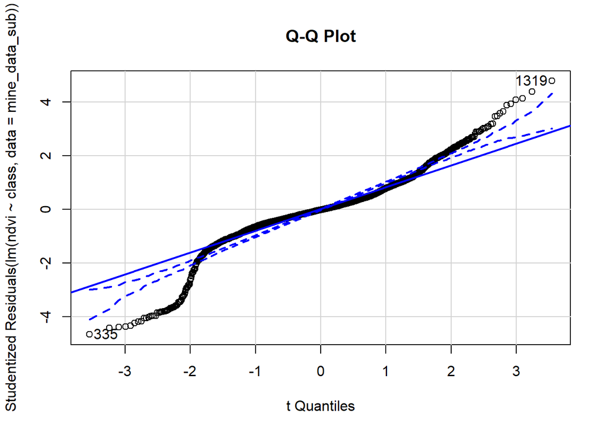

```
[1]  335 1319
```

```r
qqPlot(lm(ndvi ~ class, data = mine_data_sub), simulate = TRUE, main = "Q-Q Plot", labels = FALSE)
```

**From the plot, it can be observed that the residuals lost confidence (deviated from within the confidence interval) around the high values but mostly around the low values.This suggests that there is an issue with the normal distribution of the residuals.**

##### T15. Use the Bartlett Test of Homogeneity of Variance to assess whether there is consistent variance between the classes. What does this test suggest?

Used the Bartlett Test of Homogeneity of Variance function

```r
bartlett.test(ndvi ~ class, data = mine_data_sub)
```

```
    Bartlett test of homogeneity of variances

data:  ndvi by class
Bartlett's K-squared = 997.82, df = 2, p-value < 2.2e-16
```

**The p-value of < 2.2e-16 is statistically significant. This means that each class of land cover does not have similar variants, which is an issue.**

##### T16. Use the Bonferroni Outlier Test to test for outliers. Does this test suggest the presence of outliers?

Used the Bonferroni Outlier Test to test for outliers

```r
outlierTest(fit)
```

```
      rstudent unadjusted p-value Bonferroni p
1319  4.781929         1.8365e-06    0.0046225
335  -4.658980         3.3435e-06    0.0084156
2347 -4.422888         1.0154e-05    0.0255560
2432  4.391478         1.1724e-05    0.0295100
2345 -4.388876         1.1864e-05    0.0298630
334  -4.375322         1.2620e-05    0.0317650
2336 -4.329135         1.5556e-05    0.0391540
```

**Yes, the high values in the first column suggests that the are outliers. Justification is needed before outliers can be thrown out.**

##### T17. Use the Kruskal-Wallis Rank Sum Test to assess whether at least two cover types (“class”) have a different mean NDVI (“ndvi”). What does this test suggest?

Used the Kruskal-Wallis Rank Sum Test function

```r
kruskal.test(ndvi ~ class, data = mine_data_sub)
```

```
    Kruskal-Wallis rank sum test

data:  ndvi by class
Kruskal-Wallis chi-squared = 2164.4, df = 2, p-value < 2.2e-16
```

**The p-value of < 2.2e-16 which is less than 0.05 suggests that there is a statistical difference among atleast two of the three land cover types.**

##### T18. Use a pairwise Kruskal Wallace test to assess whether the herbaceous (“class” herb) and forest (“class” forest) types have different mean NDVI at a 95% confidence interval. What does this test suggest?

Used the pairwise Kruskal Wallace test

```r
mine_data_sub_2 <- mine_data %>% filter(class == "forest" | class == "herb") %>% select(class, ndvi)
pairw.kw(mine_data_sub_2$ndvi, mine_data_sub_2$class, conf = 0.95)
```

```
95% Confidence intervals for Kruskal-Wallis comparisons

                  Diff      Lower     Upper  Decision Adj. P-value
barren-forest     <NA>       <NA>      <NA>      <NA>         <NA>
barren-herb       <NA>       <NA>      <NA>      <NA>         <NA>
forest-herb   -132.446 -204.94142 -59.95058 Reject H0        3e-06
barren-shrub      <NA>       <NA>      <NA>      <NA>         <NA>
forest-shrub      <NA>       <NA>      <NA>      <NA>         <NA>
herb-shrub        <NA>       <NA>      <NA>      <NA>         <NA>
barren-water      <NA>       <NA>      <NA>      <NA>         <NA>
forest-water      <NA>       <NA>      <NA>      <NA>         <NA>
herb-water        <NA>       <NA>      <NA>      <NA>         <NA>
shrub-water       <NA>       <NA>      <NA>      <NA>         <NA>
```

**The p-value of 3e-06 which is less than 0.05 and rejected null hypothesis suggests that they are statistically different.**